# R Notebook

## Project: t-Tests for independent Sample (Customer Segmentation)

```r
data <- read.csv("Mall_Customers.csv")
data
```

| CustomerID | Gender | Age | Annual.Income..k.. | Spending.Score..1.100. |
| --- | --- | --- | --- | --- |
| 1 | Male | 19 | 15 | 39 |
| 2 | Male | 21 | 15 | 81 |
| 3 | Female | 20 | 16 | 6 |
| 4 | Female | 23 | 16 | 77 |
| 5 | Female | 31 | 17 | 40 |
| 6 | Female | 22 | 17 | 76 |
| 7 | Female | 35 | 18 | 6 |
| 8 | Female | 23 | 18 | 94 |
| 9 | Male | 64 | 19 | 3 |
| 10 | Female | 30 | 19 | 72 |

[output cut: 190 more lines]

```r
colnames(data)[which(colnames(data) == 'Spending.Score..1.100.')] <- 'Spending_Score'
colnames(data)[which(colnames(data) == 'Annual.Income..k..')] <- 'Annual_Income'
```

```r
View(data)
```

## Description:

Is there a difference in the average Spending_Score of customers in the mall by women and men?

variable_1 (dependent): “Spending_Score”

variable_2 (independent): “Gender”

## 1) Hypothese:

(two-sided)

H1: There is a difference between the average Spending_Score of customers in the mall by women and men. MM≠MF

H0: There is no difference between the average Spending_Score of customers in the mall by women and men. MM=MF

## 2) Requirements of t-Tests for independent Sample:

The dependent variable is min. interval scaled -> Yes, “Spending Score” is metric (dependent)

There is an independent variable by means of which the two groups to be compared are formed. -> Yes, Female und Male

The examined characteristic is normally distributed in the populations of the two groups -> Look Histogram

Homogeneity of the variances: The groups come from populations with approximately identical variance ->Look Levene-Test

The individual measured values are independent of each other (the behavior of one test person has no influence on the behavior of another) -> is given.

### Checking the normal distribution with the help of the histogram:

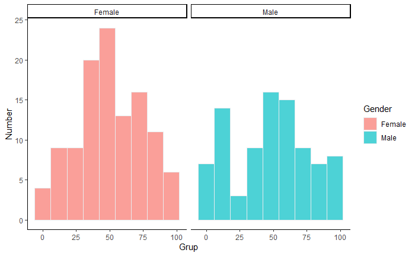

```r
library(dplyr)
library(ggplot2)

  data %>%
  group_by(Gender) %>%
  ggplot(aes(Spending_Score)) +
    geom_histogram( binwidth=12, aes(fill=Gender), color="#e9ecef", alpha=0.7 ) + # Erstelle ein Histogramm, Unterteilung, Farbe + Transparenz
   facet_wrap(~Gender)+ # Zwei Graphen
    theme_classic()+ #Farbschema
    labs(x="Grup", y="Number") # Beschriftung
```

## 3) Basic Concepts: What is t-Test for Independent Samples?

The t-test for independent samples tests whether the means of two independent samples are different. The question of the t-test for independent samples is often shortened as follows: “Are the means of two independent samples different?”

## 4) Descriptive statistics

```r
library(dplyr)
data %>%
group_by(Gender) %>%
  summarize(Anzahl = n(), Mean = mean(Spending_Score), Median = median(Spending_Score), SD = sd(Spending_Score)) %>%
  mutate_if(is.numeric, round, 2)
```

| Gender | Anzahl | Mean | Median | SD |
| --- | --- | --- | --- | --- |
| Female | 112 | 51.53 | 50 | 24.11 |
| Male | 88 | 48.51 | 50 | 27.90 |

There is a mean value difference for this question. The spending score for women (M = 51.53 SD = 24.11, n = 112) is higher than for men (M = 48.51 SD = 27.90, n = 88).

## 5) Test for homogeneity of variance (Levene-Test)

The t-test for independent groups assumes homogeneity of variance. If there is heterogeneity of variance (i.e. different variances), the degree of freedom of the t-value must be adjusted. Whether the variances are homogeneous (“equal”) can be checked with the Levene test.

The Levene test uses the null hypothesis that the two variances do not differ. A result that is not significant means that the variances do not differ and that there is homogeneity of variance. If the test is significant, heterogeneity of variance is assumed.

```r
library(car)

leveneTest(data$Spending_Score, factor(data$Gender), center = mean)
```

```
Levene's Test for Homogeneity of Variance (center = mean)
       Df F value Pr(>F)
group   1  2.2933 0.1315
      198
```

So it is recognized that there is homogeneity since the Levene test is not significant. We can therefore assume the same variances (F (1, 198) = 2.293, p = 0.1315). It is therefore not necessary to carry out a Welch correction.

with Welch-Korrektur: p < 0.05 => Result significant –> Variances heterogeneous

without Welch-Korrektur: p > 0.05 => Result not significant –> Variances homogeneous –> H0 with assumption Var1=Var2

## 6) Results of the t-test for independent samples:

The actual evaluation of the t-test takes place at this point. The t-distribution is used in the t-test. Here, you should pay attention to the order of variables, first dependent variable (spending score) and then independent variable (gender). Since a two-sided hypothesis is used in this example with a Significant Level of 0.05, “con = 0.95, alt =”two.sided" should be used. However, if you decide to use a one-sided hypothesis, then it is advisable to replace the following lines “con = 0.95, alt =”greater" depending on the direction “less” or “greater”. If there is a 1 at p-value it is exactly the other direction. “Var.eq = True” means that the variances are homogeneous (equal), or “Var.eq = False” that the variances are heterogeneous.

### Witout Welch-Korrektur:

```r
without_welch<- t.test(data$Spending_Score~data$Gender, var.eq = TRUE, con= 0.95, alt = "two.sided")
without_welch
```

```
    Two Sample t-test

data:  data$Spending_Score by data$Gender
t = 0.81905, df = 198, p-value = 0.4137
alternative hypothesis: true difference in means is not equal to 0
95 percent confidence interval:
 -4.244808 10.275652
sample estimates:
mean in group Female   mean in group Male
            51.52679             48.51136
```

The test statistic is t = 0.81905 and the associated significance value is p = 0.4137. This means that the difference is not significant: the mean values for women and men do not differ (t(198) = 0.81905, p = 0.4137)

## 7) Calculation of the Effect Size:

With groups of different sizes:

This formula uses the EffSize package - Cooper et al. (2009):

```r
library(effsize)

cohen.d(d = data$Spending_Score, f= data$Gender)
```

```
Cohen's d

d estimate: 0.1166738 (negligible)
95 percent confidence interval:
     lower      upper
-0.1644770  0.3978245
```

Interpretation of d according to Cohen (1988):

$$\begin{align}
\text{Weak Effect: } 0.20 &< ||d|| < 0.50 \\
\text{Weak to Middle Effect: } 0.50 &= ||d|| \\
\text{Middle Effect: } 0.50 &< ||d|| < 0.80 \\
\text{Middle to Strong Effect: }0.80 &= ||d|| \\
\text{Strong Effect: } 0.80 &< ||d||
\end{align}$$

This corresponds to no effect size (d = 0.116).

## 8) Summary:

The Spending_Score for women is not significantly higher (M = 51.53 SD = 24.11, n = 112) than for men (M = 48.51 SD = 27.90, n = 88). The effect size is d = 0.116 and therefore does not correspond to any effect according to Cohen (1988). H0 can not be rejected. There is no difference between the average Spending_Score of customers in the mall by women and men.